# Hw 13

```r
library("readxl")
```

# Exercise 13.17

$$H_0: \mu_1 - \mu_2 <=0$$

$$H_1: \mu_1 - \mu_2 >0$$

```r
read1317 = read_excel(path = "D:\\Xr13-17.xlsx")
attach(read1317)
```

To decide which variance test we should use:

$$H_0: \sigma_1^2/\sigma_2^2 = 1$$

$$H_1: \sigma_1^2/\sigma_2^2 != 1$$

## a.

```r
ftest1 = var.test(Tastee,Competitor,alternative = "two.sided", conf.level = 0.95)
print(ftest1)
```

```
##
##  F test to compare two variances
##
## data:  Tastee and Competitor
## F = 1.5946, num df = 14, denom df = 24, p-value = 0.305
## alternative hypothesis: true ratio of variances is not equal to 1
## 95 percent confidence interval:
##  0.6462171 4.4471640
## sample estimates:
## ratio of variances
##           1.594645
```

since p_value = 0.305 > 0.05, there’s no sufficient evidence to infer that the population variances differ. It follows that we must apply the equal-variances t-test of $\mu_1$ – $\mu_2$.

```r
ttest1 = t.test(Tastee,Competitor,alternative = "greater", mu = 0,paired = FALSE, var.equal = TRUE,conf.level = 0.95)
print(ttest1)
```

```
##
##  Two Sample t-test
##
## data:  Tastee and Competitor
## t = 4.61, df = 38, p-value = 2.227e-05
## alternative hypothesis: true difference in means is greater than 0
## 95 percent confidence interval:
##  3.535074      Inf
## sample estimates:
## mean of x mean of y
##  36.93333  31.36000
```

since p_value = 2.227e-05 <0.05, there is sufficient evidence to support that Tastee baby food is indeed superior.

## b.

```r
test1_interval = t.test(Tastee,Competitor,alternative = "two.sided", mu = 0,paired = FALSE, var.equal = TRUE,conf.level = 0.95)
print(test1_interval)
```

```
##
##  Two Sample t-test
##
## data:  Tastee and Competitor
## t = 4.61, df = 38, p-value = 4.453e-05
## alternative hypothesis: true difference in means is not equal to 0
## 95 percent confidence interval:
##  3.125913 8.020754
## sample estimates:
## mean of x mean of y
##  36.93333  31.36000
```

According to the above, there is a 95% chance that babies who eat Tastee baby food gain [3.125913 ,8.020754] more weight than those who eat Competiter’s baby food.

## c.

Draw the histograms and find out whether they are normal distribution or not.

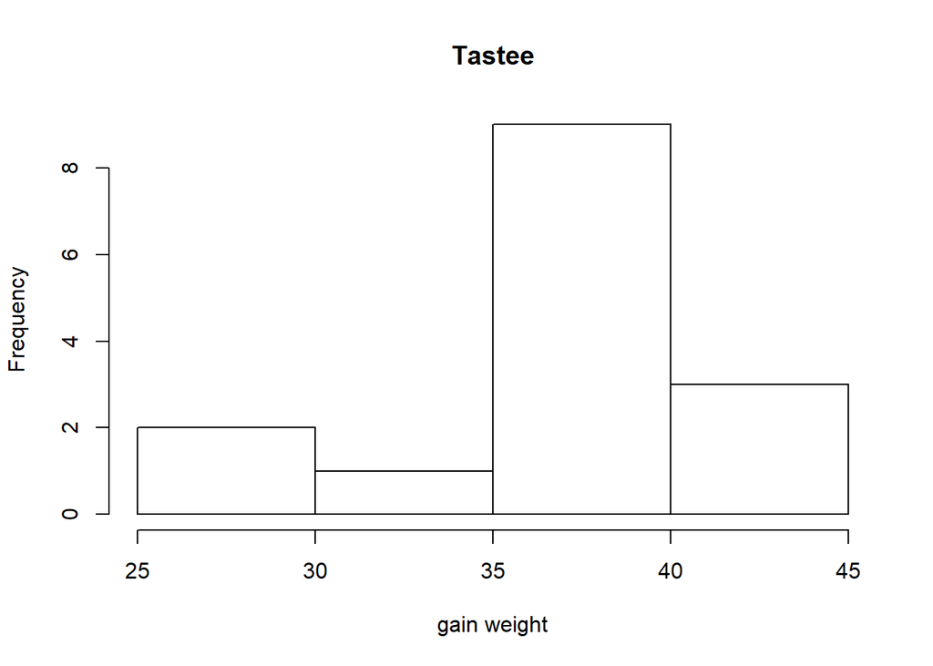

```r
hist(Tastee,xlab = "gain weight",main = "Tastee")
```

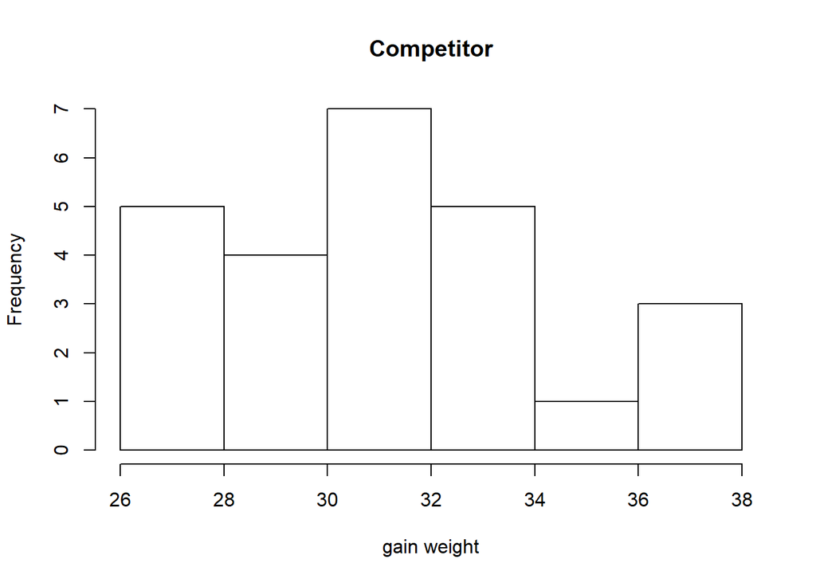

```r
hist(Competitor,xlab = "gain weight",main = "Competitor")
```

According to the charts, both Tastee and Competitor are approximately normal distribution; hence, we can ensure that the required condition is satisfied.

# Exercise 13.33

To determine whether the new tire will last longer on average than the existing car

$$H_0: \mu_1 - \mu_2 <=0$$

$$H_1: \mu_1 - \mu_2 >0$$

```r
read1333 = read_excel(path = "D:\\Xr13-33.xlsx")
attach(read1333)
```

To decide which variance test we should use:

$$H_0: \sigma_1^2/\sigma_2^2 = 1$$

$$H_1: \sigma_1^2/\sigma_2^2 != 1$$

```r
ftest2 = var.test(New,Existing,alternative = "two.sided", conf.level = 0.95)
print(ftest2)
```

```
##
##  F test to compare two variances
##
## data:  New and Existing
## F = 1.0732, num df = 19, denom df = 19, p-value = 0.8792
## alternative hypothesis: true ratio of variances is not equal to 1
## 95 percent confidence interval:
##  0.4248009 2.7114848
## sample estimates:
## ratio of variances
##           1.073239
```

since p_value = 0.8792 > 0.05, there’s no sufficient evidence to infer that the population variances differ. It follows that we must apply the equal-variances t-test of $\mu_1$ – $\mu_2$.

```r
ttest2 = t.test(New,Existing,alternative = "greater", mu = 0,paired = FALSE, var.equal = TRUE,conf.level = 0.95)
print(ttest2)
```

```
##
##  Two Sample t-test
##
## data:  New and Existing
## t = 0.90745, df = 38, p-value = 0.1849
## alternative hypothesis: true difference in means is greater than 0
## 95 percent confidence interval:
##  -3.774798       Inf
## sample estimates:
## mean of x mean of y
##      73.6      69.2
```

since p_value = 0.1849 > 0.05, there is no sufficient evidence to support that the new tire will last longer on average than the existing car.

# Exercise 13.37

To determine whether the SAT scores increased after the change in the school start time

$$H_0: \mu_1 - \mu_2 <=0$$

$$H_1: \mu_1 - \mu_2 >0$$

```r
read1337 = read_excel(path = "D:\\Xr13-37.xlsx")
attach(read1337)
```

To decide which variance test we should use:

$$H_0: \sigma_1^2/\sigma_2^2 = 1$$

$$H_1: \sigma_1^2/\sigma_2^2 != 1$$

```r
ftest3 = var.test(After,Before,alternative = "two.sided", conf.level = 0.95)
print(ftest3)
```

```
##
##  F test to compare two variances
##
## data:  After and Before
## F = 0.87629, num df = 287, denom df = 354, p-value = 0.2429
## alternative hypothesis: true ratio of variances is not equal to 1
## 95 percent confidence interval:
##  0.7037444 1.0939449
## sample estimates:
## ratio of variances
##          0.8762859
```

since p_value = 0.2429 > 0.05, there’s no sufficient evidence to infer that the population variances differ. It follows that we must apply the equal-variances t-test of $\mu_1$ – $\mu_2$.

```r
ttest3 = t.test(After,Before,alternative = "greater", mu = 0,paired = FALSE, var.equal = TRUE,conf.level = 0.95)
print(ttest3)
```

```
##
##  Two Sample t-test
##
## data:  After and Before
## t = 2.5361, df = 641, p-value = 0.005723
## alternative hypothesis: true difference in means is greater than 0
## 95 percent confidence interval:
##  5.054313      Inf
## sample estimates:
## mean of x mean of y
##  511.2917  496.8704
```

since p_value = 0.005723 <0.05, there is sufficient evidence to support that the SAT scores increased after the change in the school start time

# Exercise 13.116

To determine whether the marks differ between the two sections

$$H_0: \sigma_1^2/\sigma_2^2 = 1$$

$$H_1: \sigma_1^2/\sigma_2^2 != 1$$

```r
read13116 = read_excel(path = "D:\\Xr13-116.xlsx")
attach(read13116)
```

```r
ftest4=var.test(`Class 1`, `Class 2`, alternative = "two.sided", conf.level = 0.95)
print(ftest4)
```

```
##
##  F test to compare two variances
##
## data:  Class 1 and Class 2
## F = 3.2279, num df = 10, denom df = 10, p-value = 0.07835
## alternative hypothesis: true ratio of variances is not equal to 1
## 95 percent confidence interval:
##   0.8684583 11.9973536
## sample estimates:
## ratio of variances
##           3.227879
```

since p_value = 0.07835 > 0.05, there is no sufficient evidence to infer that the variances of the marks differ between the two sections.

# Exercise 13.117

To determine whether the limiting of max and min speeds reduce the variation in speeds

$$H_0: \sigma_1^2/\sigma_2^2 = 1$$

$$H_1: \sigma_1^2/\sigma_2^2 < 1$$

```r
read13117 = read_excel(path = "D:\\Xr13-117.xlsx")
attach(read13117)
```

```r
ftest5=var.test(`Week 2`, `Week 1`, alternative = "less", conf.level = 0.95)
print(ftest5)
```

```
##
##  F test to compare two variances
##
## data:  Week 2 and Week 1
## F = 0.65528, num df = 99, denom df = 99, p-value = 0.01832
## alternative hypothesis: true ratio of variances is less than 1
## 95 percent confidence interval:
##  0.0000000 0.9135046
## sample estimates:
## ratio of variances
##           0.655283
```

since p_value = 0.01832 < 0.05, there is sufficient evidence to infer that the limiting of max and min speeds reduce the cariation in speeds